# El Dorado

A Data Science Competition

Mick Cooney

March 27, 2017

# Background

# Dublin R - May 2016

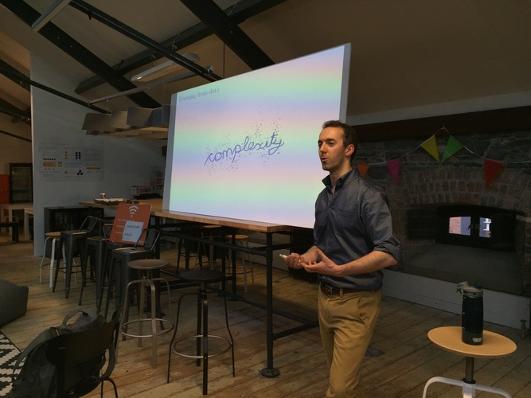

Pat O’Reilly - AllState

“Anyone can fit an elephant”

Regularisation

L1, L2, ElasticNet

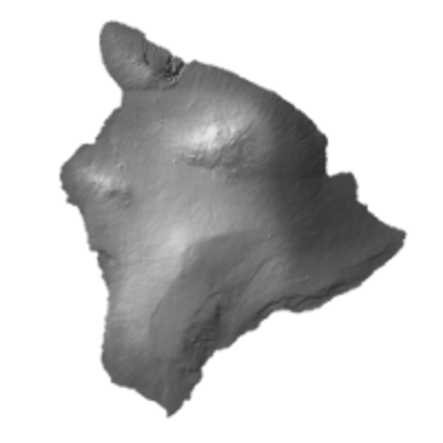

Island with gold reserves $\rightarrow$ Predict deposits

[figure not shown]

Never a good thing

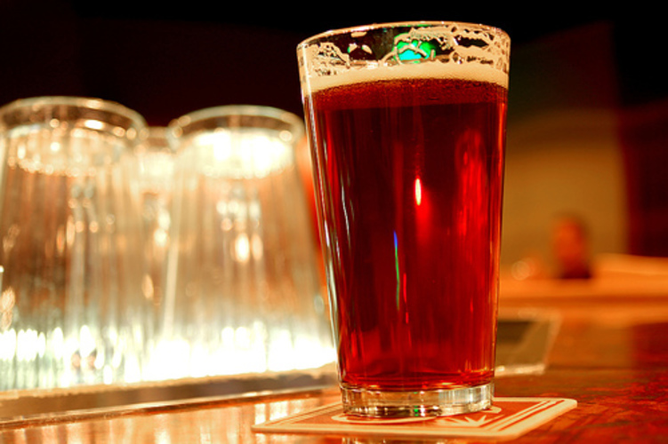

“That would be really cool!”

“You should definitely do that”

“So how are you thinking of generating the data…”

# The El Dorado Competition

# Basic Idea

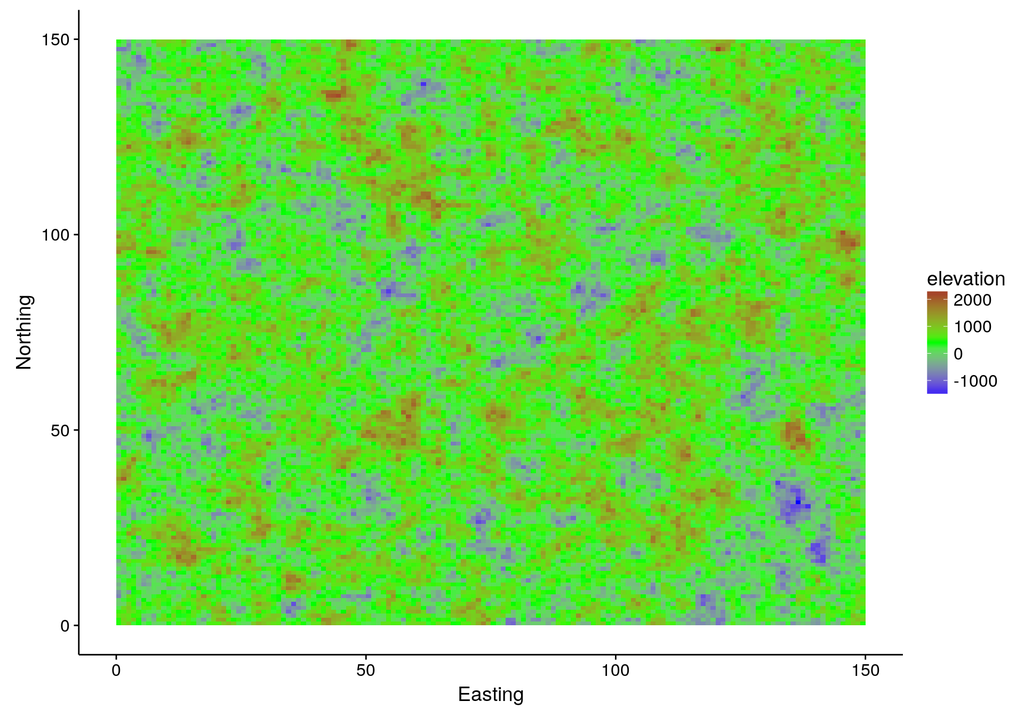

Mine gold, make profit

Bid price, extraction costs, profit margins

# Design Goals

Emphasise use of prediction, accuracy less important

Something for everyone

Vickrey auction: Highest bidder wins, pays second highest price

Easy to understand, code, fast to run

Harder to ‘game’

Starting capital

50 parcels of land, sequential auctions

$$\text{Score} = \text{Start} - \text{Bids Paid} - \text{Extraction Costs} + \text{Sales}$$

# Logistics

# Generating Data

Online datasets pointless

How do I generate data?

[figure not shown]

Make it up!

Hard to reverse engineer

No ‘true’ model

2D Gaussian Processes

$$150 \times 150 = 22,500 \; \text{land parcels}$$

Tested with simple models

# Submissions

5,000 parcels in training set

Team submits bids for each parcel

```
## parcel_id,bid_amount
## 515,734503.19
## 914,883127.20
## 1538,56130.52
```

Simple Shiny app

CSV upload with time stamp

Buggy as hell - didn’t work at all

Manual submissions - emails

Never again!

12 submissions

[figure not shown]

# Results

# Results Night

Facebook, mid-September 2016

7-8 teams

Most teams single person

Speakers described approach (5-10 mins)

Clustering, Cersei Lannister, Qlik

Mini-competitions

Hospital

# Final Scores

- 3rd Place (54,468,017)
- 2nd Place (55,418,322)
- 1st Place (96,020,955)

### Winning Approach

Unsophisticated model

Use variables to predict unknown variables to then predict gold

Focus on most profitable parcels

Overspend on auctions

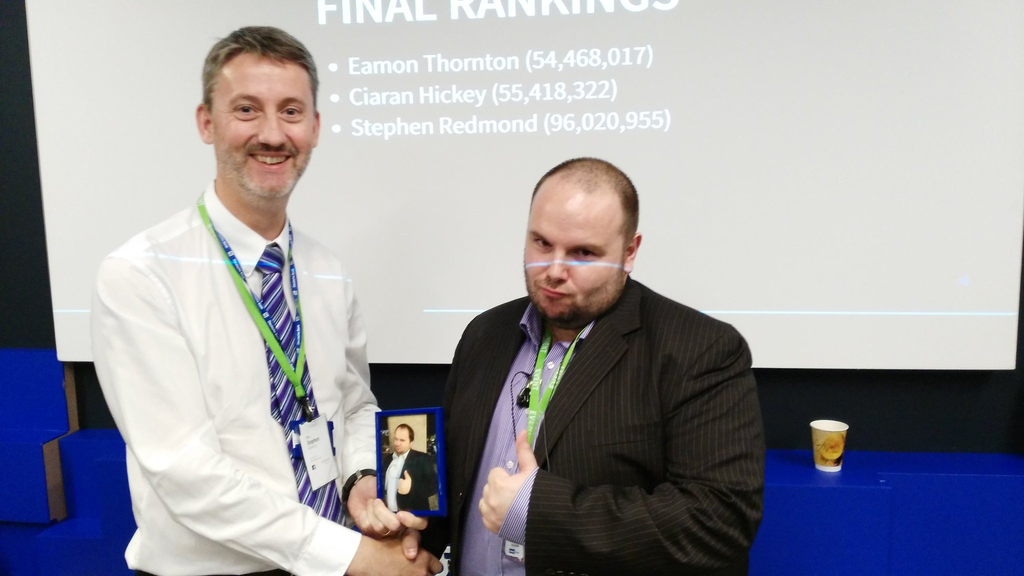

# The Future

# The Cannonball Run Competition

Pricing car insurance

Competitive quotes

Most money wins

Coming Soon to an Internet Near You!

# Any Questions?

mickcooney@gmail.com

michael.cooney@barnett-waddingham.co.uk

https://github.com/kaybenleroll/dublin_r_workshops

(talk_mldeldorado_201703)